##Loading data and checking alignment

```r
metadata = readRDS('metadata_in_vitro.rds')
head(metadata)
```

```
##            donor treatment disease sex age ethnicity
## GSM3993154  HC-1        CS healthy   F  67 Caucasian
## GSM3993155  HC-1        CS healthy   F  67 Caucasian
## GSM3993156  HC-1        CS healthy   F  67 Caucasian
## GSM3993157  HC-1       air healthy   F  67 Caucasian
## GSM3993158  HC-1       air healthy   F  67 Caucasian
## GSM3993159  HC-1       air healthy   F  67 Caucasian
```

```r
str(metadata)
```

```
## 'data.frame':    36 obs. of  6 variables:
##  $ donor    : Factor w/ 6 levels "COPD-1","COPD-2",..: 4 4 4 4 4 4 5 5 5 5 ...
##  $ treatment: Factor w/ 2 levels "air","CS": 2 2 2 1 1 1 2 2 2 1 ...
##  $ disease  : Factor w/ 2 levels "healthy","COPD": 1 1 1 1 1 1 1 1 1 1 ...
##  $ sex      : Factor w/ 2 levels "F","M": 1 1 1 1 1 1 1 1 1 1 ...
##  $ age      : num  67 67 67 67 67 67 42 42 42 42 ...
##  $ ethnicity: Factor w/ 3 levels "Black","Caucasian",..: 2 2 2 2 2 2 3 3 3 3 ...
```

```r
dim(metadata)
```

```
## [1] 36  6
```

```r
gene_counts = readRDS("data_in_vitro_gene.rds")
dim(gene_counts)
```

```
## [1] 67186    36
```

```r
gene_counts[1:6, 1:6]
```

```
##                 GSM3993154 GSM3993155 GSM3993156 GSM3993157 GSM3993158
## ENSG00000000003       5996      10415      12017      10313       9012
## ENSG00000000005          1          2          2          8          4
## ENSG00000000419       1115       1236       1353       1079       1132
## ENSG00000000457       1342       2009       2253       1984       1551
## ENSG00000000460        246        320        340        347        305
## ENSG00000000938          4          4         11          7          7
##                 GSM3993159
## ENSG00000000003      11776
## ENSG00000000005          6
## ENSG00000000419       1345
## ENSG00000000457       2087
## ENSG00000000460        364
## ENSG00000000938         13
```

```r
head(colnames(gene_counts))
```

```
## [1] "GSM3993154" "GSM3993155" "GSM3993156" "GSM3993157" "GSM3993158"
## [6] "GSM3993159"
```

```r
head(rownames(gene_counts))
```

```
## [1] "ENSG00000000003" "ENSG00000000005" "ENSG00000000419" "ENSG00000000457"
## [5] "ENSG00000000460" "ENSG00000000938"
```

```r
metadata = metadata[colnames(gene_counts), ]
all(colnames(gene_counts) == rownames(metadata))
```

```
## [1] TRUE
```

## Data quality control

The first check determined if there were any missing values, neagtive values, and what the minimum and maximum counts are, as well as the decimal values of the results

```r
sum(is.na(gene_counts))
```

```
## [1] 0
```

```r
sum(gene_counts < 0)
```

```
## [1] 0
```

```r
range(gene_counts)
```

```
## [1]       0 2541310
```

```r
sum(gene_counts %% 1 !=0)
```

```
## [1] 0
```

Next the genes with a zero count will be removed

```r
gene_count_filter = gene_counts[rowSums(gene_counts) > 0, ]

dim(gene_counts)
```

```
## [1] 67186    36
```

```r
dim(gene_count_filter)
```

```
## [1] 51646    36
```

The samples have been reduced down to 51646 genes

```r
library_size = colSums(gene_count_filter)
library_size
```

```
## GSM3993154 GSM3993155 GSM3993156 GSM3993157 GSM3993158 GSM3993159 GSM3993160
##   43985652   63622959   59814280   52000744   43649436   54590652   66167920
## GSM3993161 GSM3993162 GSM3993163 GSM3993164 GSM3993165 GSM3993166 GSM3993167
##   53923802   91072429   65593604   55002771   69544901   45030792   50152899
## GSM3993168 GSM3993169 GSM3993170 GSM3993171 GSM3993172 GSM3993173 GSM3993174
##   59100023   64878826   79498287   47842708   72543121   84827302   88153517
## GSM3993175 GSM3993176 GSM3993177 GSM3993178 GSM3993179 GSM3993180 GSM3993181
##   64772093   68891955   69988319   36404474   45639563   31713307   42281978
## GSM3993182 GSM3993183 GSM3993184 GSM3993185 GSM3993186 GSM3993187 GSM3993188
##   43064700   41871567   73867027   78596576   53206373   61876475   55180571
## GSM3993189
##   46981687
```

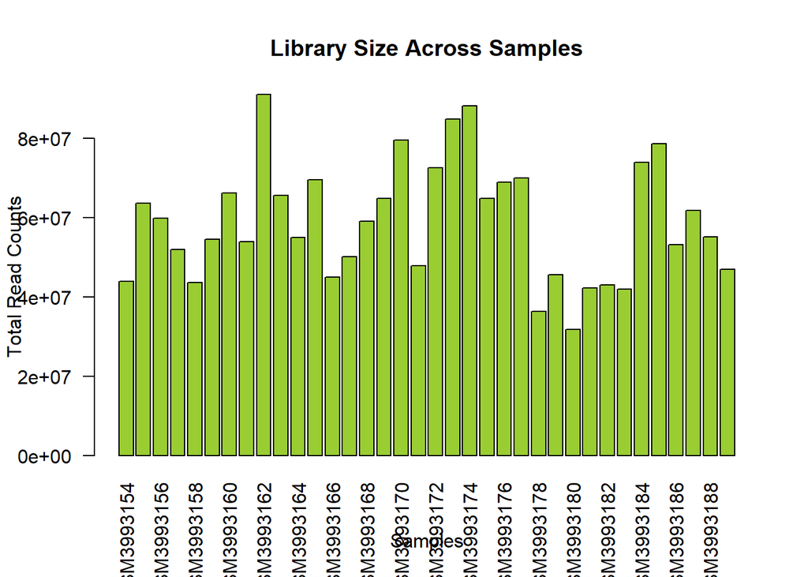

```r
barplot(library_size, las = 2,
        main = "Library Size Across Samples",
        ylab = "Total Read Counts",
        xlab = "Samples",
        col = "olivedrab3")
```

visualising the library size distribution

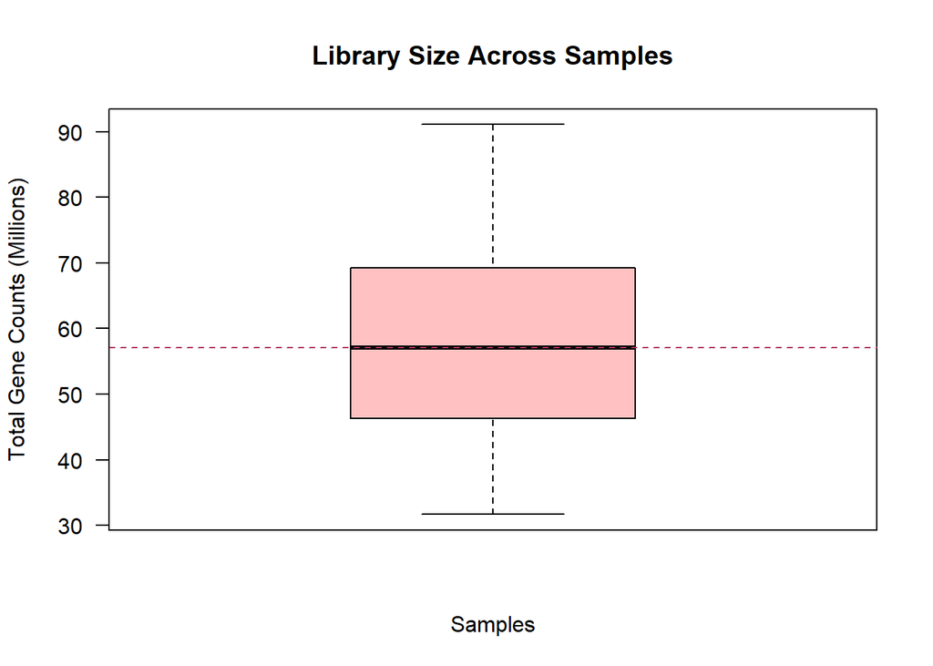

```r
boxplot(library_size / 1e6,
        main = "Library Size Across Samples",
        ylab = "Total Gene Counts (Millions)",
        xlab = "Samples",
        col = "rosybrown1",
        las = 2)
abline(h = median(library_size / 1e6),
       col = "maroon",
       lty = 2)
```

- No obvious outliers
- average is almost 60 million reads
- largest sample is approximatley 90 million reads
- smallest sample is approximately 30 million reads

## PCA

```r
library(DESeq2)
colnames(metadata)
```

```
## [1] "donor"     "treatment" "disease"   "sex"       "age"       "ethnicity"
```

```r
table(metadata$treatment)
```

```
##
## air  CS
##  18  18
```

```r
table(metadata$donor)
```

```
##
## COPD-1 COPD-2 COPD-3   HC-1   HC-2   HC-3
##      6      6      6      6      6      6
```

```r
donor = factor(metadata$donor)
treatment = factor(metadata$treatment)
treatment = relevel(metadata$treatment, ref = "air")



dds = DESeqDataSetFromMatrix(countData = gene_count_filter, colData = metadata, design =  ~ donor + treatment)
```

```
##   Note: levels of factors in the design contain characters other than
##   letters, numbers, '_' and '.'. It is recommended (but not required) to use
##   only letters, numbers, and delimiters '_' or '.', as these are safe characters
##   for column names in R. [This is a message, not a warning or an error]
```

```r
dds
```

```
## class: DESeqDataSet
## dim: 51646 36
## metadata(1): version
## assays(1): counts
## rownames(51646): ENSG00000000003 ENSG00000000005 ... ENSG00000290162
##   ENSG00000290166
## rowData names(0):
## colnames(36): GSM3993154 GSM3993155 ... GSM3993188 GSM3993189
## colData names(6): donor treatment ... age ethnicity
```

```r
dds = DESeq(dds)
```

```
##   Note: levels of factors in the design contain characters other than
##   letters, numbers, '_' and '.'. It is recommended (but not required) to use
##   only letters, numbers, and delimiters '_' or '.', as these are safe characters
##   for column names in R. [This is a message, not a warning or an error]
```

```
##   Note: levels of factors in the design contain characters other than
##   letters, numbers, '_' and '.'. It is recommended (but not required) to use
##   only letters, numbers, and delimiters '_' or '.', as these are safe characters
##   for column names in R. [This is a message, not a warning or an error]
```

```r
resultsNames(dds)
```

```
## [1] "Intercept"              "donor_COPD.2_vs_COPD.1" "donor_COPD.3_vs_COPD.1"
## [4] "donor_HC.1_vs_COPD.1"   "donor_HC.2_vs_COPD.1"   "donor_HC.3_vs_COPD.1"
## [7] "treatment_CS_vs_air"
```

```r
results = results(dds, name = "treatment_CS_vs_air")
summary(results)
```

```
##
## out of 51646 with nonzero total read count
## adjusted p-value < 0.1
## LFC > 0 (up)       : 8967, 17%
## LFC < 0 (down)     : 11283, 22%
## outliers [1]       : 54, 0.1%
## low counts [2]     : 10012, 19%
## (mean count < 1)
## [1] see 'cooksCutoff' argument of ?results
## [2] see 'independentFiltering' argument of ?results
```

```r
head(results)
```

```
## log2 fold change (MLE): treatment CS vs air
## Wald test p-value: treatment CS vs air
## DataFrame with 6 rows and 6 columns
##                   baseMean log2FoldChange     lfcSE      stat      pvalue
##                  <numeric>      <numeric> <numeric> <numeric>   <numeric>
## ENSG00000000003 9870.87711    -0.12723180 0.1086525 -1.170997 0.241599907
## ENSG00000000005    4.24103    -0.74095204 0.3298782 -2.246138 0.024695153
## ENSG00000000419 1240.01850     0.05800461 0.0441801  1.312913 0.189212172
## ENSG00000000457 2095.58736    -0.03796108 0.0677664 -0.560176 0.575359492
## ENSG00000000460  329.83114    -0.00585724 0.0577038 -0.101505 0.919149273
## ENSG00000000938    8.20518     1.03740829 0.2985850  3.474415 0.000511969
##                       padj
##                  <numeric>
## ENSG00000000003 0.35235791
## ENSG00000000005 0.05787535
## ENSG00000000419 0.29076214
## ENSG00000000457 0.67901783
## ENSG00000000460 0.94637051
## ENSG00000000938 0.00249536
```

upregulated - genes w higher expression after CS exposure compared to air downregulated - genes w lower expression after CS exposure compared to air

more genes were downregulated

Determining the most significant genes:

```r
res_ordered = results[order(results$padj), ]
head(res_ordered, 10)
```

```
## log2 fold change (MLE): treatment CS vs air
## Wald test p-value: treatment CS vs air
## DataFrame with 10 rows and 6 columns
##                  baseMean log2FoldChange     lfcSE      stat       pvalue
##                 <numeric>      <numeric> <numeric> <numeric>    <numeric>
## ENSG00000138061 25843.780        3.95436  0.155725   25.3932 2.99904e-142
## ENSG00000138798   495.575        2.50097  0.114062   21.9264 1.45364e-106
## ENSG00000140465 17240.582        6.95767  0.331790   20.9701  1.23081e-97
## ENSG00000145423   223.369        4.11870  0.206211   19.9732  9.42110e-89
## ENSG00000134873  3633.677        2.62505  0.137889   19.0374  8.35278e-81
## ENSG00000109906  1301.538       -2.37358  0.137408  -17.2739  7.39505e-67
## ENSG00000105388  4098.030        3.46303  0.200747   17.2508  1.10418e-66
## ENSG00000184347   106.279       -2.42572  0.143994  -16.8459  1.12453e-63
## ENSG00000087842  1618.213        1.82826  0.108936   16.7828  3.25832e-63
## ENSG00000103257  8135.111        3.67591  0.223127   16.4745  5.59047e-61
##                         padj
##                    <numeric>
## ENSG00000138061 1.24700e-137
## ENSG00000138798 3.02211e-102
## ENSG00000140465  1.70591e-93
## ENSG00000145423  9.79323e-85
## ENSG00000134873  6.94618e-77
## ENSG00000109906  5.12477e-63
## ENSG00000105388  6.55880e-63
## ENSG00000184347  5.84474e-60
## ENSG00000087842  1.50534e-59
## ENSG00000103257  2.32452e-57
```

```r
res_sig = results[!is.na(results$padj) & results$padj < 0.1, ]
dim(res_sig)
```

```
## [1] 20250     6
```

```r
table(metadata$donor, metadata$treatment)
```

```
##
##          air CS
##   COPD-1   3  3
##   COPD-2   3  3
##   COPD-3   3  3
##   HC-1     3  3
##   HC-2     3  3
##   HC-3     3  3
```

```r
table(metadata$disease, metadata$treatment)
```

```
##
##           air CS
##   healthy   9  9
##   COPD      9  9
```

### Volcano Plot

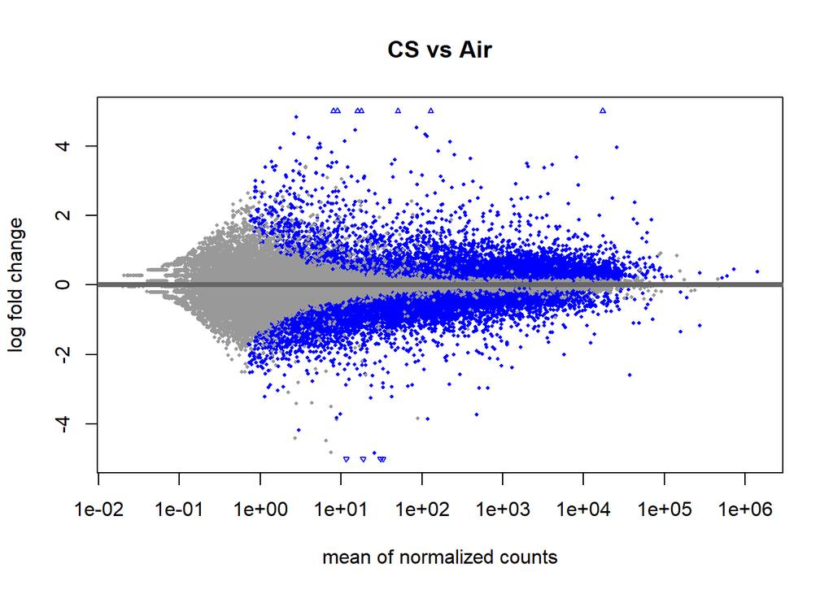

```r
plotMA(results,
       main = "CS vs Air",
       ylim = c(-5,5))
```

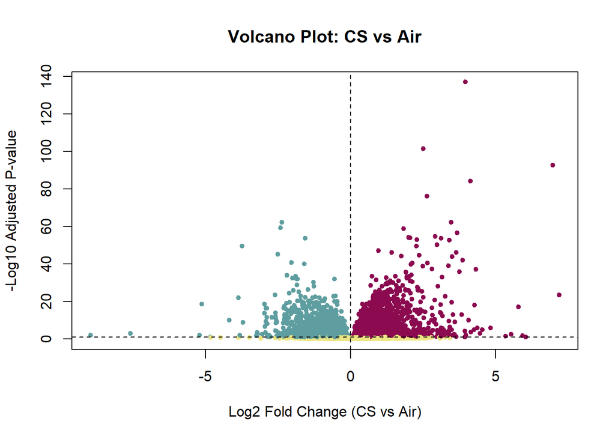

```r
plot(results$log2FoldChange,
     -log10(results$padj),
     pch = 20,
     col = ifelse(results$padj < 0.1 & results$log2FoldChange > 0, "deeppink4",

                  ifelse(results$padj < 0.1 & results$log2FoldChange < 0,
                         "cadetblue", "khaki2")),
     xlab = "Log2 Fold Change (CS vs Air)",
     ylab = "-Log10 Adjusted P-value",
     main = "Volcano Plot: CS vs Air")

abline(v = 0, lty = 2)
abline(h = -log10(0.1), lty = 2)
```

Red - upregulated genes Blue - Significantly downregulated genes Yellow - not statistically significant genes

```r
vsd = vst(dds, blind = FALSE)
pcaData = plotPCA(vsd,
                  intgroup = c("treatment", "donor"),
                  returnData = TRUE)
```

```
## using ntop=500 top features by variance
```

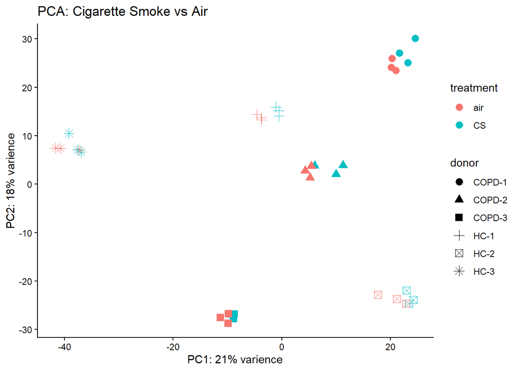

```r
percentVar = round(100* attr(pcaData, "percentVar"))


library(ggplot2)
ggplot(pcaData, aes(
  x = PC1,
  y = PC2,
  colour = treatment,
  shape = donor
))+
  geom_point(size = 3)+
  xlab(paste0("PC1: ", percentVar[1], "% varience"))+
  ylab(paste0("PC2: ", percentVar[2], "% varience"))+
  ggtitle("PCA: Cigarette Smoke vs Air")+
  theme_classic()
```

clustering by primary donor rather than treatment - donor specific differences are a major source of variation in gene expression

Heatmap:

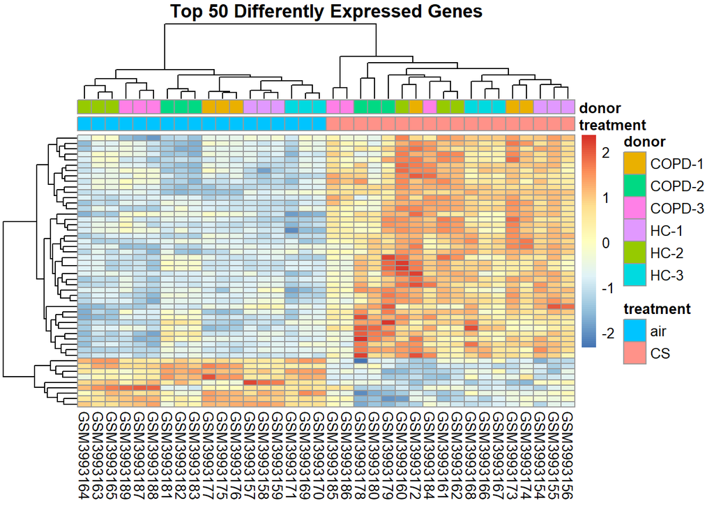

```r
if (!requireNamespace("pheatmap", quietly = TRUE)) {
  install.packages("pheatmap")
}

library(pheatmap)
top_genes = head(rownames(res_ordered),50)

heatmap_data = assay(vsd)[top_genes, ]
heatmap_scaled = t(scale(t(heatmap_data)))

annotation = as.data.frame(colData(vsd)[, c("treatment", "donor")])
rownames(annotation) = colnames(heatmap_scaled)


pheatmap(heatmap_scaled,
         annotation_col = annotation,
         show_rownames = FALSE,
         main = "Top 50 Differently Expressed Genes")
```

higher expression in CS (red) air has a lower relative expression (blue) in the same genes expression patterns differ between treatment groups ## DEG List

```r
write.csv(as.data.frame(res_sig),
          "CS_vs_Air_significant_DEGs.csv")

write.csv(as.data.frame(results),
          "CS_vs_Air_all_DEG_results.csv")
```